# Pooled analysis of indomethacin PK data: Answer

Metrum Research Group

# 1 Packages

```r
library(tidyverse)
library(mrgsolve)
theme_set(theme_bw())
```

# 2 Load indomethacin data set

```r
data(Indometh)
```

- Take a look at what is there

```r
head(Indometh)
```

```
.   Subject time conc
. 1       1 0.25 1.50
. 2       1 0.50 0.94
. 3       1 0.75 0.78
. 4       1 1.00 0.48
. 5       1 1.25 0.37
. 6       1 2.00 0.19
```

```r
count(Indometh, Subject)
```

```
.   Subject  n
. 1       1 11
. 2       4 11
. 3       2 11
. 4       5 11
. 5       6 11
. 6       3 11
```

# 3 Data assembly

- Assume single 25 mg dose for all individuals
- Setting `cmt` to 0 for observations
- Setting `cmt` to 2 for doses … will need a model where the second compartment is `central`

```r
obs <- as.data.frame(Indometh) %>%
  mutate(evid = 0, cmt = 0, ID = as.numeric(Subject))

dose <-
  distinct(obs, ID) %>%
  mutate(amt = 25, time = 0, conc = NA, evid = 1, cmt = 2)
```

- Put it back together

```r
data <-
  bind_rows(obs, dose) %>%
  arrange(ID, time) %>%
  mutate(Subject = NULL)


head(data)
```

```
.   time conc evid cmt ID amt
. 1 0.00   NA    1   2  1  25
. 2 0.25 1.50    0   0  1  NA
. 3 0.50 0.94    0   0  1  NA
. 4 0.75 0.78    0   0  1  NA
. 5 1.00 0.48    0   0  1  NA
. 6 1.25 0.37    0   0  1  NA
```

- Take `dv` as a vector of observed concentrations

```r
dv <- obs$conc
```

# 4 Create an objective function function

- For starters, just do OLS estimation
- Note that we *need* to name the parameters `p`
  - Parameter updates require names in `mrgsolve`
  - Generally, don’t expect `p` to retain any names that you might pass in through the initial estimates
- We also pass in the `data` and the dependent variable (`dv`)

```r
obj <- function(p, theta, data, dv, pred = FALSE, obsonly = TRUE) {

  names(p) <- names(theta)

  p <- lapply(p,exp)

  mod <- param(mod, p)

  out <- mrgsim(mod, data = data, obsonly=obsonly)

  if(pred) return(as.data.frame(out))

  return(sum(((out$CP - dv))^2))
}
```

# 5 Load a PK model

- We’ll try out one-compartment first

```r
mod <- mread_cache("pk1", modlib())

param(mod)
```

```
.
.  Model parameters (N=3):
.  name value . name value
.  CL   1     | V    20
.  KA   1     | .    .
```

# 6 Fit with one-compartment model

- First generate some initial estimates
- These *need* to be named in a way that is consistent with the model we are using
- I usually run a test with the objective function function to make sure the logic works out

```r
theta <- log(c(CL = 1, V = 100))

obj(theta,theta,data,dv)
```

```
. [1] 33.69619
```

- Nelder-Mead optimization

```r
fit <- optim(par = theta, fn=obj, theta = theta, data=data, dv=dv)
```

- And generate some predictions based on the final estimates

```r
pred <- obj(fit$par, theta, data, dv, pred = TRUE, obsonly = FALSE)

data$pred <- pred$CP

head(data)
```

```
.   time conc evid cmt ID amt      pred
. 1 0.00   NA    1   2  1  25 2.7771715
. 2 0.25 1.50    0   0  1  NA 1.9814023
. 3 0.50 0.94    0   0  1  NA 1.4136524
. 4 0.75 0.78    0   0  1  NA 1.0085852
. 5 1.00 0.48    0   0  1  NA 0.7195857
. 6 1.25 0.37    0   0  1  NA 0.5133960
```

# 7 Make a plot of the output

- What do you think? Good fit?

```
. Warning: Removed 6 rows containing missing values (geom_point).
```

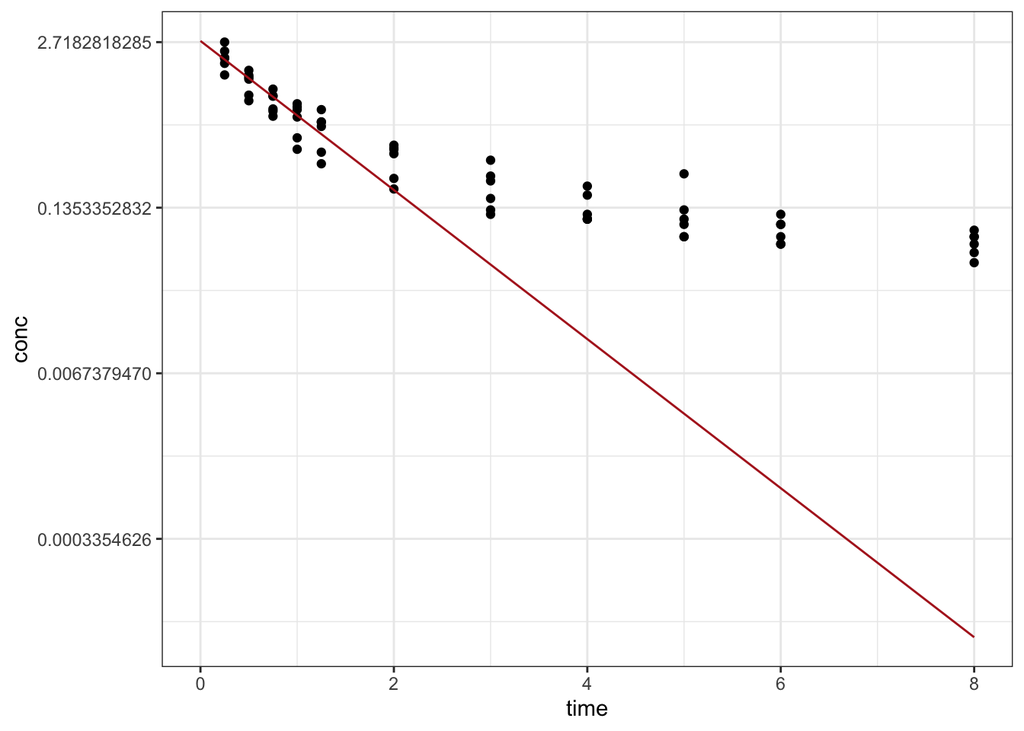

```r
ggplot(data = data) +
  geom_point(aes(time,conc)) +
  scale_y_continuous(trans="log") +
  geom_line(aes(time,pred),col="firebrick")
```

# 8 Your turn

- Load a 2 compartment model

```r
mod <- mread_cache("pk2", modlib())
```

- Take a look at the model and generate a call to `minqa::newuoa` using the OLS objective function above to fit the data
- You will also need try out a new set of initial estimates for all of the volumes and clearances for 2-compartment, IV bolus model
- What do you think of the fit using the the OLS objective function?
  - Can you make a simple modification to the OLS objective function that might make the fit look a little better?
- Suppose we’re worried about the `newuoa` optimizer and want to try a global search algorithm
  - Can you construct a call to `RcppDE::DEoptim` that will also fit the data?
  - Remember that `DEoptim` doesn’t use initial estimates the same way `stats::optim` or `minqa::newuoa` does; you have to specify one vector of lower boundaries and one vector of upper boundaries, with a lower and upper bound for each parameter

# 9 Answer

- Set the initial estimates for two compartment model

```r
param(mod)
```

```
.
.  Model parameters (N=5):
.  name value . name value
.  CL   1     | V2   20
.  KA   1     | V3   10
.  Q    2     | .    .
```

```r
theta <- log(c(CL = 2, V2 = 20, Q = 5, V3 = 20))
```

- Try weighted least squares

```r
obj <- function(p, theta, data, dv, pred = FALSE, obsonly = TRUE) {

  names(p) <- names(theta)

  p <- lapply(p,exp)

  mod <- param(mod, p)

  out <- mrgsim(mod, data = data, obsonly=obsonly)

  if(pred) return(as.data.frame(out))

  return(sum(((out$CP - dv)/dv)^2))
}
```

```r
fit <- minqa::newuoa(par = theta, fn=obj, theta = theta, data=data, dv=dv)
```

Final estimates and final value of objective function

```r
exp(fit$par)
```

```
. [1]  8.926544  8.873480  6.319329 19.684325
```

```r
obj(fit$par,theta,data,dv)
```

```
. [1] 4.635543
```

- Generate predictions for the final and initial estimates

```r
pred <-  obj(fit$par, theta, data, dv, pred = TRUE, obsonly = FALSE)
predi <- obj(theta,  theta, data, dv, pred = TRUE, obsonly = FALSE)


data$pred <- pred$CP
data$predi <- predi$CP
head(data)
```

```
.   time conc evid cmt ID amt      pred     predi
. 1 0.00   NA    1   2  1  25 2.8173839 1.2500000
. 2 0.25 1.50    0   0  1  NA 1.8483732 1.1475299
. 3 0.50 0.94    0   0  1  NA 1.2371869 1.0576684
. 4 0.75 0.78    0   0  1  NA 0.8505655 0.9787893
. 5 1.00 0.48    0   0  1  NA 0.6049256 0.9094775
. 6 1.25 0.37    0   0  1  NA 0.4478397 0.8485009
```

- Plot the predictions

```
. Warning: Removed 6 rows containing missing values (geom_point).
```

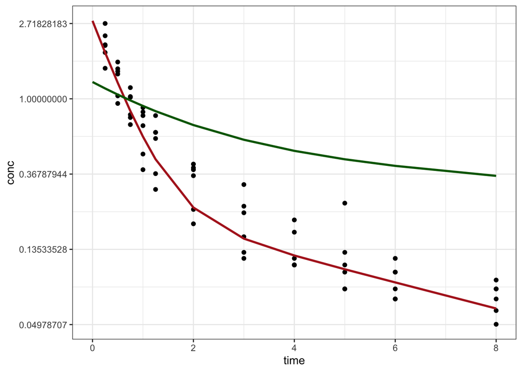

```r
pred <- distinct(data, time, .keep_all = TRUE)

ggplot(data = data) +
  geom_point(aes(time,conc)) +
  scale_y_continuous(trans="log") +
  geom_line(data=pred,aes(time,pred),col="firebrick", lwd=1) +
  geom_line(data=pred,aes(time,predi),col="darkgreen", lwd=1)
```

## 9.1 Fit the data with `RcppDE::DEoptim`

```r
fit <- RcppDE::DEoptim(obj, lower = rep(-4,4), upper = rep(4,4),
                       theta = theta, data = data, dv = dv)
```

## 9.2 Check the estimates and the final value of the objective function

```r
exp(fit$optim$bestmem)

obj(fit$optim$bestmem, theta,data,dv)
```

[output not shown]